# Titanic: Integrated Decision Tree, Clustering analysis and Visualization using R/Tableau

Rony Chacko

## Integrated Analysis - Decision Tree and K-means Clustering using Tableau/R

In this example, I’ll use the famed Titanic dataset to examine which group had the highest probability of survival. I’ll demonstrate Decision Trees and K-means clustering in R and then move on to Tableau to visualize survival ratios of each cluster. I’ll be demonstrating Data retrieval, Data pre-processing, Decision Tree analysis using R and finally integrated K-mean cluster analysis using Tableau/R integration by invoking Rserve()

```r
# 1. Data Retrieval
titanic <- read.csv('titanic.csv')
dim(titanic)
```

```
## [1] 891  12
```

## Preprocessing

Impute missing ages in the data using the mean age Categorize ages into 5 bins Factorize the Survived, Passenger Class, Age Category, Embarked station features Remove features that will not be used for analysis

```r
# 2. Data preprocessing
meanAge <- sum(na.omit(titanic$Age))/length(na.omit(titanic$Age))

titanic$Age[is.na(titanic$Age)] <- meanAge
titanic$Age <- round(titanic$Age)

titanic$AgeCat[titanic$Age >= 0  & titanic$Age <= 16] <- "0-16"
titanic$AgeCat[titanic$Age >= 17 & titanic$Age <= 32] <- "17-32"
titanic$AgeCat[titanic$Age >= 33 & titanic$Age <= 48] <- "33-48"
titanic$AgeCat[titanic$Age >= 49 & titanic$Age <= 64] <- "49-64"
titanic$AgeCat[titanic$Age >= 65] <- "65 and Above"

titanic$Survived[titanic$Survived == 0] <- "Not Survived"
titanic$Survived[titanic$Survived == 1] <- "Survived"

titanic$Pclass <- factor(titanic$Pclass)
titanic$AgeCat <- factor(titanic$AgeCat)
titanic$Survived <- factor(titanic$Survived)
titanic$Embarked <- as.character(titanic$Embarked)
titanic$Embarked[titanic$Embarked == 'S'] <- 'Southampton'
titanic$Embarked[titanic$Embarked == 'C'] <- 'Cherbourg'
titanic$Embarked[titanic$Embarked == 'Q'] <- 'Queenstown'
titanic$Embarked <- factor(titanic$Embarked)

titanic <- titanic[c(-9,-11)]
```

View the structure of the dataset after the transformations

```r
str(titanic)
```

```
## 'data.frame':    891 obs. of  11 variables:
##  $ PassengerId: int  1 2 3 4 5 6 7 8 9 10 ...
##  $ Survived   : Factor w/ 2 levels "Not Survived",..: 1 2 2 2 1 1 1 1 2 2 ...
##  $ Pclass     : Factor w/ 3 levels "1","2","3": 3 1 3 1 3 3 1 3 3 2 ...
##  $ Name       : Factor w/ 891 levels "Abbing, Mr. Anthony",..: 109 191 358 277 16 559 520 629 417 581 ...
##  $ Sex        : Factor w/ 2 levels "female","male": 2 1 1 1 2 2 2 2 1 1 ...
##  $ Age        : num  22 38 26 35 35 30 54 2 27 14 ...
##  $ SibSp      : int  1 1 0 1 0 0 0 3 0 1 ...
##  $ Parch      : int  0 0 0 0 0 0 0 1 2 0 ...
##  $ Fare       : num  7.25 71.28 7.92 53.1 8.05 ...
##  $ Embarked   : Factor w/ 3 levels "Cherbourg","Queenstown",..: 3 1 3 3 3 2 3 3 3 1 ...
##  $ AgeCat     : Factor w/ 5 levels "0-16","17-32",..: 2 3 2 3 3 2 4 1 2 1 ...
```

## Decision Tree analysis

Decision tree works best for the categorical variables hence I will convert two variables SibSp and Parch into categorical variables and add the variables (vectors) to the data.

```r
# 3. Decision Tree
decision_tree <- titanic
SibSpCat <- ifelse(decision_tree$SibSp >= 3, ">=3", "<3")
decision_tree <- data.frame(decision_tree, SibSpCat)
decision_tree$SibSpCat <- as.factor(decision_tree$SibSpCat)
ParchCat <- ifelse(decision_tree$Parch >=3, ">=3", "<3")
decision_tree <- data.frame(decision_tree, ParchCat)
decision_tree$ParchCat <- as.factor(decision_tree$ParchCat)
```

Separate data into “training data” and “testing data”. I will use training data to build the tree and test its accuracy using the testing data.

```r
# 3.2 Data partitioning
set.seed(1)
test = sample(1:nrow(decision_tree), nrow(decision_tree)/3)
train = -test
training_data = decision_tree[train, ]
testing_data = decision_tree[test, ]
testing_survived = decision_tree$Survived[test]
```

Load libraries

```r
# 3.3 Load libs
library(rpart)
library(RGtk2)
library(rattle)
```

```r
library(rpart.plot)
library(RColorBrewer)
```

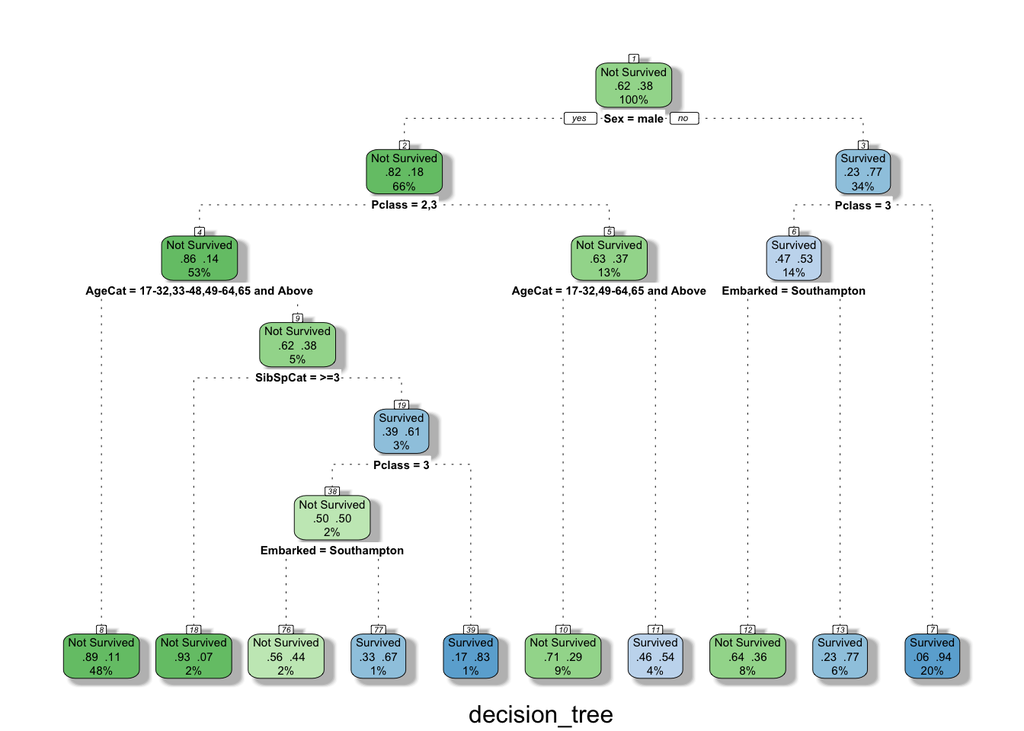

```r
# 3.4 Building the Tree and draw the decision tree
tree_model <- rpart(Survived ~ Pclass + Sex + AgeCat +
                      Embarked + SibSpCat +
                      ParchCat, data = training_data, method = "class",
                    control = rpart.control(minsplit = 10, cp=0.00))
fancyRpartPlot(tree_model, sub = "decision_tree")
```

Now predict the survival rates using the model

```r
# 3.5 Use the model to predict survival rate
tree_predict <- predict(tree_model, testing_data, type = "class")
```

Check the misclassification rate of the model

```r
# 3.6 Check the misclassification rate
mean(tree_predict != testing_survived)
```

```
## [1] 0.2188552
```

Review the classification matrix

```r
# 3.7 Check classification matrix
table(testing_survived, tree_predict)
```

```
##                 tree_predict
## testing_survived Not Survived Survived
##     Not Survived          158       24
##     Survived               41       74
```

Some interesting insights from the Decision Tree analysis. The misclassification rate is 21.9%. Note the first variable used for splitting is Sex. The ratio of survived:not-survived initially is 38:62. Ratio of Females survived:not-survived is 77:23. The top 5 variables from my decision tree that has an impact on surivability in decreasing order of importance are - Sex, Pclass, Embarked, SibSpCat, AgeCat

## K-means clustering

From the above analysis, I know what variables to focus on for the clustering. Since the variables selected in the above step are categorical variables and clustering requires continuous values, I will convert the following categorical variables to continuous - Sex, Embarked, Survived

```r
titanicUpdated <- titanic
SurvivedNum <- ifelse(titanicUpdated$Survived == "Not Survived", 0, 1)
titanicUpdated <- data.frame(titanicUpdated, SurvivedNum)

SexN <- ifelse(titanicUpdated$Sex == "male", 1, 0)
titanicUpdated <- data.frame(titanicUpdated, SexN)

EmbarkedN <- ifelse(titanicUpdated$Embarked == "Southampton", 1, ifelse(titanicUpdated$Embarked == "Cherbourg", 2, 0))
titanicUpdated <- data.frame(titanicUpdated, EmbarkedN)
```

Before the cluster analysis one has to select for the optimum number of clusters. I’ll normalize the data and find the total number of clusters required by plotting the sum of sqaured errors

```r
titanic.scaled <- scale(data.frame(titanic$Age, titanic$Parch, titanic$SibSp, titanic$Fare))
#colnames(titanic.scaled)
totwss <- vector()
btwss <- vector()

for(i in 2:15)
{
  set.seed(1234)
  temp <- kmeans(titanic.scaled, centers = i)
  totwss[i] <- temp$tot.withinss
  btwss[i] <- temp$betweenss
}
```

Plot total-within-sum-of-squared-errors

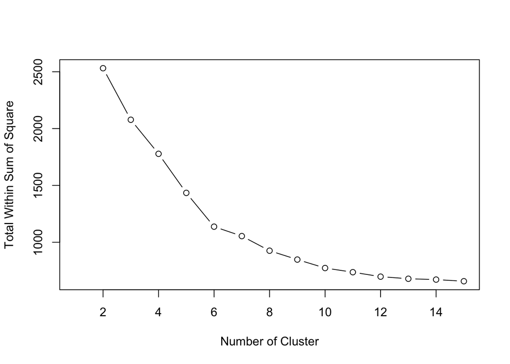

```r
plot(totwss, xlab = "Number of Cluster", type = "b", ylab = "Total Within Sum of Square")
```

Plot total-between-sum-of-squared-errors

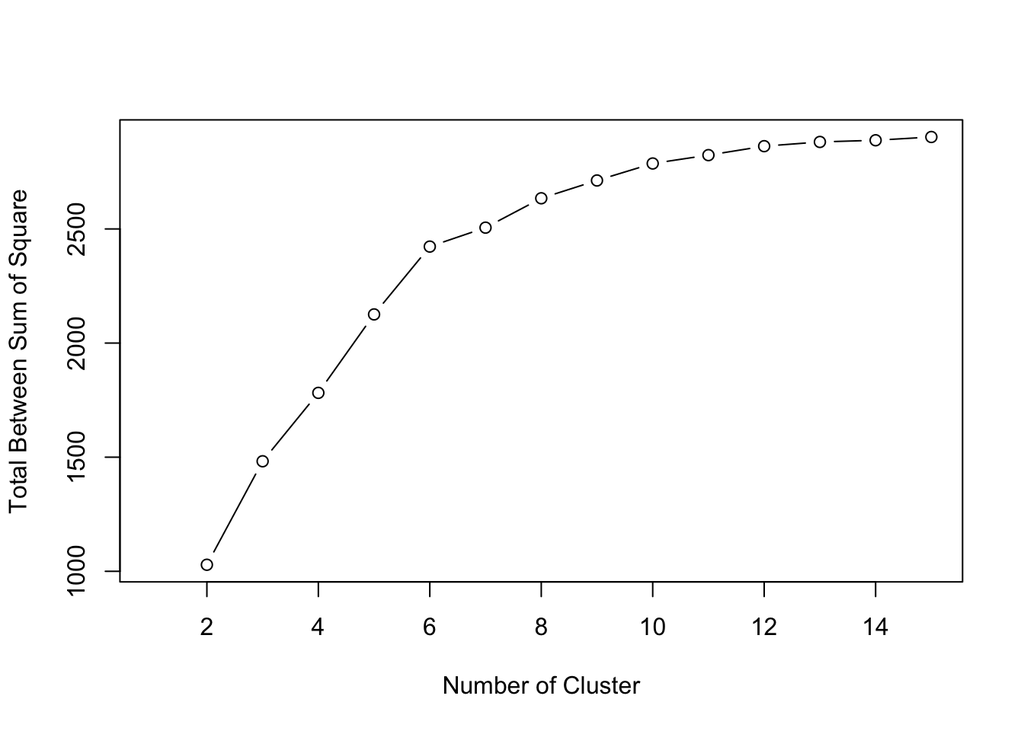

```r
plot(btwss, xlab = "Number of Cluster", type = "b", ylab = "Total Between Sum of Square")
```

The total WSS measures the compactness of the clustering and we want it to be as small as possible. The Elbow method looks at the total WSS as a function of the number of clusters. One should choose a number of clusters so that adding another cluster doesn’t improve much better the total WSS. The location of the bend in the plot is generally considered as an indicator of the appropriate number of clusters. In this case, the bend occurs at 6 clusters.

Now that I know know what the optimum number of clusters to be used in my integrated analysis, what clustering variables are important? At this juncture, I will perform visual analysis integrating Tableau with R to visualize the clusters in Tableau. Click here to see the remaining analysis in Tableau.